# R Notebook

```r
library(tidyverse)
library(janitor)
library(ggfortify)
library(GGally)
# install.packages("raster")
library(raster)
library(leaflet)

housing <- read_csv("data/housing_prices.csv")
```

Notes:

- What does one row represent? An aggregate of a district in California
- Some variables are raw sums, some are “stats”, like averages –> do some feature engineering variable transformation to get more “stats” that are meaningful to me about these houses

Lets do some “feature engineering” - The data set we start with is te “raw materials” - We can use those to make more meaning, aid interpretation

```r
housing <- housing %>%
  mutate(bedrooms_per_house = total_bedrooms / households,
         rooms_per_house = total_rooms / households,
         people_per_house = population / households,
         bedrooms_per_person = bedrooms_per_house / people_per_house,
         rooms_per_person = total_rooms / population,
         bedrooms_per_room = total_bedrooms / total_rooms,
         non_bedrooms_per_house = rooms_per_house - bedrooms_per_house,
  )
```

- Extra idea: start using long & lats to make more meaning –> joining to external city coordinate data, creating labels, flags, or things like “distance to city”

Let’s explore the relationships between teh variables - what looks like it influences price?

```r
ggpairs1 <- housing %>%
  select(median_house_value,
         housing_median_age,
         median_income,
         ocean_proximity) %>%
  ggpairs()

ggpairs1

ggpairs2 <- housing %>%
  select(median_house_value,
         total_rooms,
         rooms_per_house,
         total_bedrooms,
         bedrooms_per_house) %>%
  ggpairs()

ggpairs2

ggpairs3 <- housing %>%
  select(median_house_value,
         households,
         population,
         people_per_house,
         total_rooms,
         rooms_per_house) %>%
  ggpairs()

ggpairs3
```

[interactive chart not shown]

Log Transformations

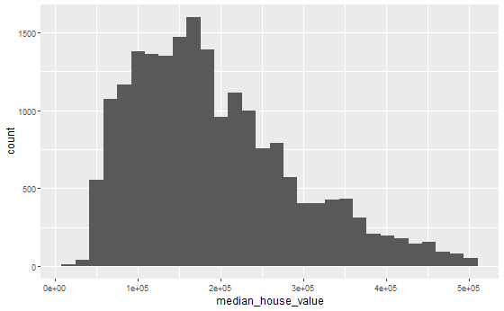

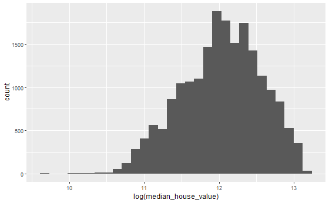

# 1 MVP

## 1 Load the housing_prices.csv data set and undertake an initial exploration of the data

```r
glimpse(housing)
summary(housing)
head(housing)

housing %>%
  summarise(across(.fns = ~sum(is.na(.x))))

# total bedrooms has all the NA values
```

##2 We expect the total_rooms of houses to be strongly correlated with total_bedrooms. Use ggpairs() to investigate correlations between these two variables

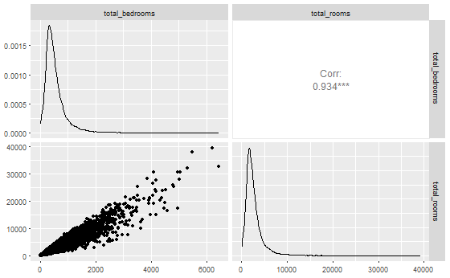

##3 So, we do find significant correlations. Let’s drop total_bedrooms from the dataset, and use only total_rooms going forward.

```r
housing <- housing %>%
  select(-total_bedrooms)
```

##4 We are interesting in developing a regression model for the median_house_value of a house in terms of the possible predictor variables in the dataset. 1. Use ggpairs() to investigate correlations between median_house_value and the predictors 2. Perform further ggplot visualisations of any significant correlations

[figure not shown]

##5 Shortly we may try a regression model to fit the categorical predictor ocean_proximity. Investigate the level of ocean_proximity predictos. How many dummy variables do you expect to get from it?

```r
unique(housing$ocean_proximity)
```

```
[1] "NEAR BAY"   "<1H OCEAN"  "INLAND"     "NEAR OCEAN" "ISLAND"
```

##6 Start with simple linear regression. Regress median_house_value on median_income and check the regression diagnostics.

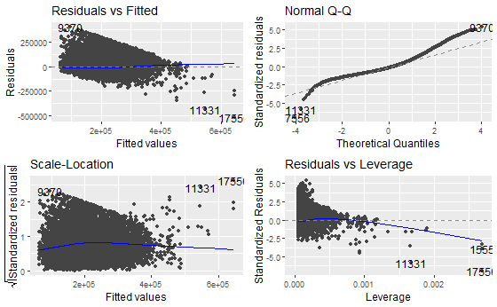

##7 Add another predictor of your choice. Check your assumptions, diagnotstics, and interpret the model

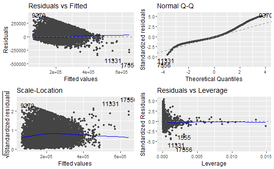

## Extension

##8 Try adding an interaction between log(median_income) and your chosen categorical predictor. Do you think this interaction term is statisticlaly justified?